# Yuqi_EDA

Yuqi Miao ym2771

4/20/2022

# Data exploration

## barplot at each time point

verify poisson might be less reasonable

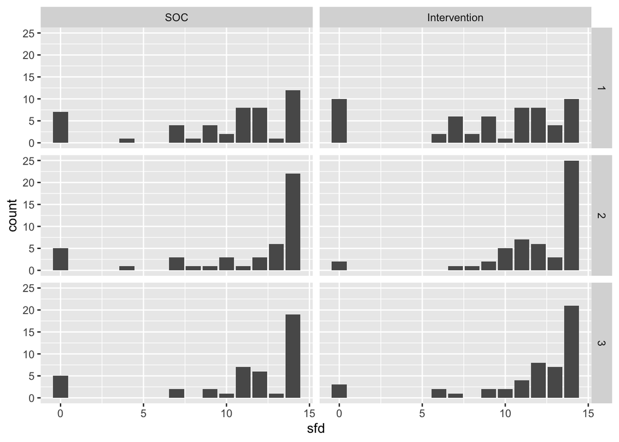

```r
data %>%
  ggplot(aes(x = sfd))+
  geom_bar()+
  facet_grid(time~group)
```

- heavy tail, not appropriate for poisson count

## barplot for 6 v.s. baseline and 12 v.s. baseline

- 2 goal:
  - see distribution to verify normal trend – middle high, 2 tail low
  - see if the control/trt group have roughly equan variance to decide 2 sample t test with equal/unequal var (continous)

```r
data_change = data %>%
  pivot_wider(id_cols = c(id, school,group),
              names_from = time,
              values_from = sfd,
              names_prefix = "time"
              ) %>%
  mutate(m6_m0 = time2-time1,
         m12_m0 = time3-time1) %>%
  pivot_longer(c(m6_m0, m12_m0),
               names_to = "compare",
               values_to = "sfd_change") %>%
  mutate(compare = factor(compare, levels = c("m6_m0", "m12_m0")))

sum_dc = data_change %>%
  group_by(compare, group) %>%
  summarize(mean = mean(sfd_change, na.rm = T),
            median = median(sfd_change, na.rm = T))
```

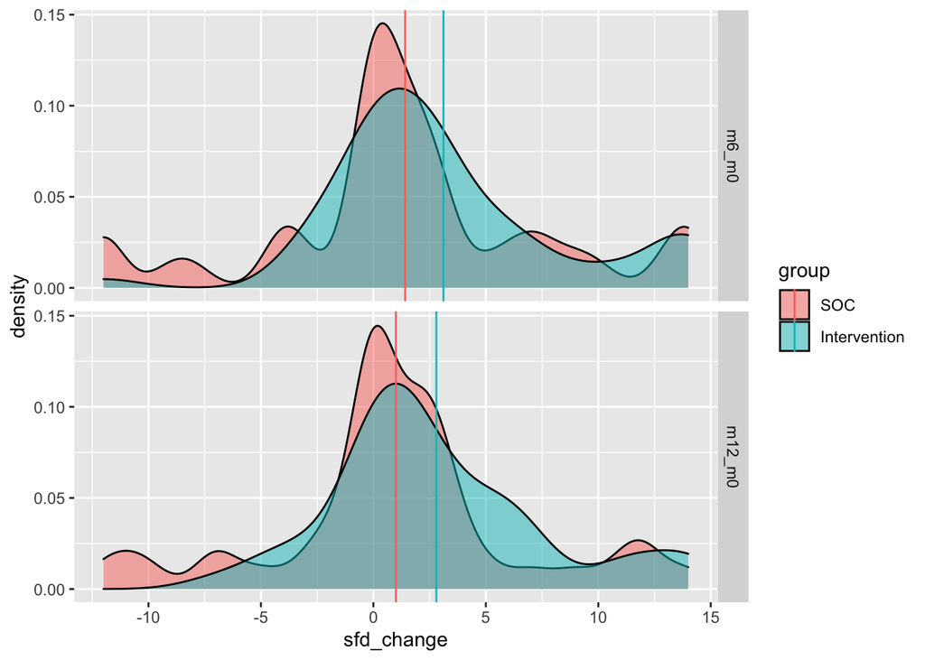

```r
data_change %>%
  # filter(compare == "m6_m0") %>%
  ggplot(aes(x = sfd_change, fill = group))+
  # geom_histogram()+
  geom_density(alpha = 0.5)+
  geom_vline(data = sum_dc, aes(xintercept = mean,color = group))+
  facet_grid(compare~.)
```

- Truely a normal like distribution, but with right tail
- different vairance: larger variance in the intervention group!

## sphagetti plot

Goal: Disprove the linear trend and conduct the analysis using time as categorical/ independent measures

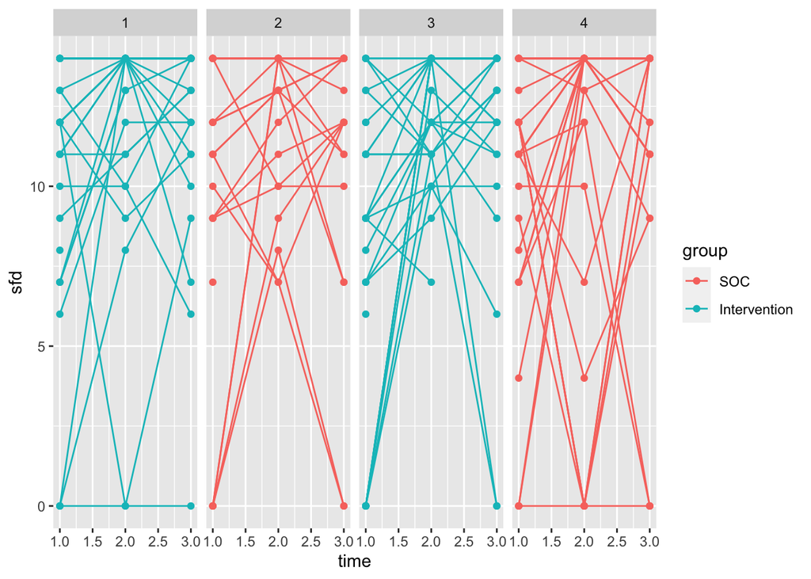

```r
sp_dc = data_change %>%
  ggplot(aes(x = compare, y = sfd_change, color = group, group = id))+
  geom_line()+
  geom_point()+
  facet_grid(.~school)

sp_sfd = data %>%
  ggplot(aes(x = time, y = sfd,color = group, group = id))+
  geom_line()+
  geom_point()+
  facet_grid(.~school)

sp_sfd
```

- by sp_sfd, no clear linear trend along time, not appropriate to treat time as continuous variable
- Box/point plot for intra-class correlation visualization, facet by month. (https://dcricollab.dcri.duke.edu/sites/NIHKR/KR/Intraclass_Correlation_Coefficient_Cheat_Sheet_March_15_2020.pdf)

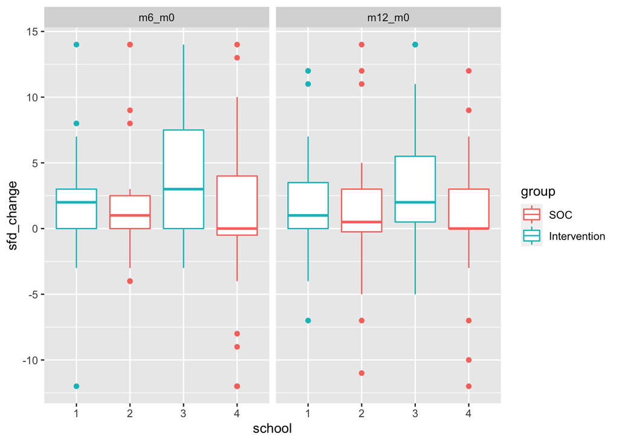

```r
data_change %>%
  ggplot(aes(x = school, y = sfd_change, color = group))+
  geom_boxplot()+
  facet_grid(.~compare)
```

- Both btw/within group correlation

# Pilot study analysis

```r
g = lmer(sfd_change~group*compare +(1|school)+(1|id),
           data = data_change)
# g = lmer(sfd_change~group*compare +(1|school)+(1|id),
#            data = data_change %>%
#            mutate(compare = factor(compare, levels = c("m12_m0","m6_m0"))))

summary(g)
```

```
## Linear mixed model fit by REML. t-tests use Satterthwaite's method [
## lmerModLmerTest]
## Formula: sfd_change ~ group * compare + (1 | school) + (1 | id)
##    Data: data_change
##
## REML criterion at convergence: 1135.2
##
## Scaled residuals:
##      Min       1Q   Median       3Q      Max
## -2.56582 -0.22731 -0.02552  0.34630  2.33952
##
## Random effects:
##  Groups   Name        Variance Std.Dev.
##  id       (Intercept) 19.2155  4.3835
##  school   (Intercept)  0.3569  0.5974
##  Residual             10.7257  3.2750
## Number of obs: 191, groups:  id, 100; school, 4
##
## Fixed effects:
##                                 Estimate Std. Error       df t value Pr(>|t|)
## (Intercept)                      1.41477    0.90940  3.01925   1.556    0.217
## groupIntervention                1.66507    1.25582  2.78033   1.326    0.283
## comparem12_m0                   -0.07978    0.70754 91.96528  -0.113    0.910
## groupIntervention:comparem12_m0 -0.26024    0.96552 91.55871  -0.270    0.788
##
## Correlation of Fixed Effects:
##             (Intr) grpInt cm12_0
## grpIntrvntn -0.724
## comprm12_m0 -0.369  0.267
## grpInt:12_0  0.271 -0.368 -0.733
```

```r
# texreg::texreg(g)
confint(g)
```

```
## Computing profile confidence intervals ...
```

```
##                                      2.5 %   97.5 %
## .sig01                           3.6119696 5.241621
## .sig02                           0.0000000 1.838266
## .sigma                           2.8190136 3.771404
## (Intercept)                     -0.2540151 3.106087
## groupIntervention               -0.6856968 3.973679
## comparem12_m0                   -1.4663528 1.306667
## groupIntervention:comparem12_m0 -2.1470619 1.635781
```

```r
summary(g)$coefficients
```

```
##                                    Estimate Std. Error        df    t value
## (Intercept)                      1.41476519  0.9093964  3.019247  1.5557190
## groupIntervention                1.66506808  1.2558193  2.780329  1.3258819
## comparem12_m0                   -0.07978432  0.7075432 91.965281 -0.1127625
## groupIntervention:comparem12_m0 -0.26024260  0.9655160 91.558714 -0.2695373
##                                  Pr(>|t|)
## (Intercept)                     0.2170577
## groupIntervention               0.2832821
## comparem12_m0                   0.9104646
## groupIntervention:comparem12_m0 0.7881227
```

## estimation of ICC

```r
vc = as_tibble(VarCorr(g))
sigma2_2 = vc$vcov[[1]]
sigma2_3 = vc$vcov[[2]]
sigma2_e = vc$vcov[[3]]
```

### if assuming 2 level

```r
rho = sigma2_3/(sigma2_2+sigma2_3)
```

### if assuming 3 level

```r
rho1 = (sigma2_2+sigma2_3)/(sigma2_2+sigma2_3+sigma2_e)
rho2 = (sigma2_3)/(sigma2_2+sigma2_3+sigma2_e)
```

# Study design

## If using continuous outcome and 3 level structure:[1]

$$y_{ijk} = \beta_0+\delta_{(3)}X_{ijk}+\mu_i+\mu_{j_{i}}+e_{ijk}$$

- i for school, j for subjects, k for measures
- $\mu_i \sim N(0, \sigma_3^2)$ random intercept for school
- $\mu_{j_{i}}\sim N(0, \sigma_2^2)$ random intercept for school random intercept for subject
- randomize on school level, $X_{ijk} = X_i = 0/1$ indicating the control/intervention
- Hypothesis: $H_0: \delta_{(3)} = 0$,$H_1: \delta_{(3)} \neq 0$
  - **Q**: $H_1: \delta_{(3)} > 0?$
- calculate N based on normal distribution, with multiple adjustment: $\alpha* = \alpha/4 = 0.05/4 = 0.0125$ for the 4 comparison;
- $\beta = 0.2$

$$N_2 = \frac{2(1+(\rho_1-\rho_2)N_1-\rho_1)Z_{\alpha, \beta}^2}{N_1N_3\Delta^2-2\rho_2N_1Z_{\alpha, \beta}^2}$$

```r
alpha_star = 0.025/4 # multiple test adjust
# alpha_star = 0.025 # no multiple test adjust
beta = 0.2
z_ab = -qnorm(alpha_star)-qnorm(beta)
delta = 1/3
N3 = 15
N1 = 4
N2 = (2*(1+(rho1-rho2)*N1-rho1)*z_ab^2)/(N1*N3*delta^2-2*rho2*N1*z_ab^2)
N_star = N3*N2
```

## If using continuous outcome and 2 level structure:

- $\bar X \sim N(\mu_i, \sigma^2)$
- Hypothesis: $H_0: \mu_i-\mu_c \leq\frac{\sigma^2}{3}$, $H_1: \mu_i-\mu_c>\frac{\sigma^2}{3}$
  - Assuming equal variance?
- calculate N based on normal distribution, with multiple adjustment: $\alpha* = \alpha/4 = 0.05/4 = 0.0125$ for the 4 comparison;
- $\beta = 0.2$
- $2N = \frac{4(Z_\alpha*+Z_{\beta})}{(1/3)^2} = \frac{4*(2.241403+0.8416212)}{(1/3)^2}$
- calculate ICC: $\rho=\frac{S_b^2}{S_b^2+S_w^2}$

```r
N = (2*(-qnorm(0.0125)-qnorm(0.2))^2/(1/3)^2)
m = (1-rho)/(15/N-rho)
N_star = N*(1+(m-1)*rho)
```

- In each treat arm, we need 212.0771133 samples, indicating 14.1384742 samples per school

# resource

[1]Ahn, C., Heo, M., & Zhang, S. (2014). Sample size calculations for clustered and longitudinal outcomes in clinical research. CRC Press.